# Instrumental Variables

Encouragement Designs, ITT, LATE, and Two-Stage Least Squares

Professor Benjamin Noble

## Part I

## State of the Union Address

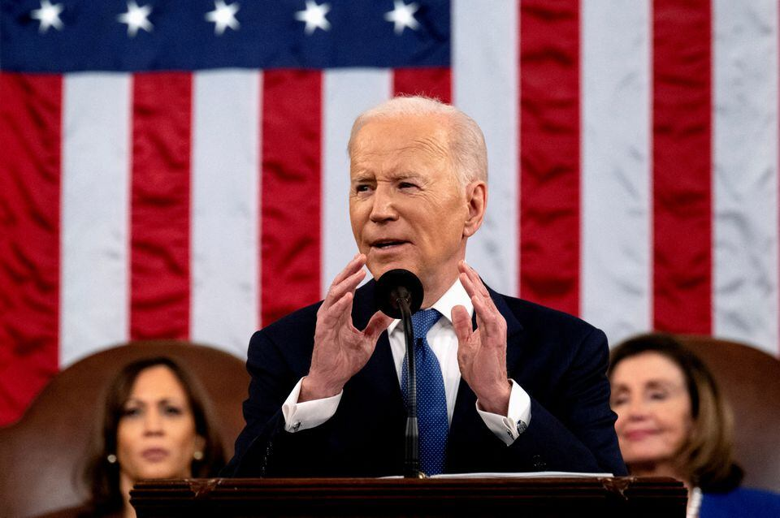

[figure not shown]

## The Selection Problem

- The headline is about State of the Union **watchers**, not a random sample.
- When the president is a Democrat, Democrats are more likely to watch.
- Controlling for party isn’t enough: Republicans who *did* watch differ from typical Republicans.

## Visualizing the Problem (and Solution)

- **$D_i$ (treatment):** Watched the State of the Union Address.
- **$Y_i$ (outcome):** Felt proud or optimistic afterward.
- **$U_i$ (confounder):** Party ID, political interest (unobserved factors that drive both watching and pride).
- **$Z_i$ (instrument):** Randomly encouraged to watch.

## Randomizing the Encouragement

## Compliance

- **Compliers:** take treatment when encouraged and do not take treatment when not encouraged.
  $$[D_i \mid Z_i = 1] = 1 \ \text{and} \ [D_i \mid Z_i = 0] = 0$$
- But…some people do not comply.
  - **Always-takers:** $[D_i \mid Z_i = 1] = [D_i \mid Z_i = 0] = 1$
  - **Never-takers:** $[D_i \mid Z_i = 1] = [D_i \mid Z_i = 0] = 0$
  - **Defiers:** $[D_i \mid Z_i = 1] = 0$ and $[D_i \mid Z_i = 0] = 1$
- The treatment effect can only be assessed for compliers.

## We Don’t See the Counterfactual

|  | $D_i = 1$ (takes treatment) | $D_i = 0$ (no treatment) |
| --- | --- | --- |
| $Z_i = 1$ (encouraged) | complier *or* always-taker | defier *or* never-taker |
| $Z_i = 0$ (not encouraged) | defier *or* always-taker | complier *or* never-taker |

## Some Assumptions

- **Ignorability of the instrument:** $(Y_i^1, Y_i^0) \perp Z_i$
- **Exclusion restriction:** $Z$ (instrument) only affects $Y$ (outcome) through $D$ (treatment). We cannot test the exclusion restriction. It must be defended theoretically.
- **No weak instruments** (relevance): $\mathbb{E}[ D_i | Z_i = 1] - \mathbb{E}[ D_i | Z_i = 0] \neq 0$
- **No defiers** (monotonicity).

## Intent-to-Treat Effect

- Effect of being encouraged to take the treatment
  $$\mathbb{E}[Y_i \mid Z_i = 1] - \mathbb{E}[Y_i \mid Z_i = 0]$$
- $$\frac{1+1+1+0+0}{5} - \frac{1+1+0+0+0}{5}$$
  $$= \frac{3}{5} - \frac{2}{5} = 0.2$$
- Equivalent to a regression of $Y$ on $Z$.

| id | z | d | y |
| --- | --- | --- | --- |
| 1 | 1 | 1 | 1 |
| 2 | 1 | 1 | 1 |
| 3 | 1 | 1 | 1 |
| 4 | 1 | 0 | 0 |
| 5 | 1 | 1 | 0 |
| 6 | 0 | 1 | 1 |
| 7 | 0 | 0 | 1 |
| 8 | 0 | 0 | 0 |
| 9 | 0 | 0 | 0 |
| 10 | 0 | 0 | 0 |

## Why This “Works”

- $Z$ (encouragement) is randomly assigned.
- **Exclusion restriction** ensures any change in $Y$ caused by $Z$ operates entirely through $D$ (no other pathways).
- If $Z$ is relevant/not weak, then some proportion of our sample consists of compliers.
  - Compliers drive the ITT. Always-takers and never-takers contribute nothing to the effect, but don’t distort its direction.
- There are no defiers (they cannot flip the sign of our estimate).

## Decomposing the ITT

$$ITT = ITT_c \times \Pr(c) + ITT_a \times \Pr(a) + ITT_n \times \Pr(n) + ITT_d \times \Pr(d)$$

$$ITT = ITT_c \times \Pr(c) + ITT_a \times \Pr(a) + ITT_n \times \Pr(n) + ITT_d \times 0 \;\;\text{(no defiers)}$$

$$ITT = ITT_c \times \Pr(c) + 0 \times \Pr(a) + 0 \times \Pr(n) + 0 \times \Pr(d) \;\;\text{(exclusion restriction)}$$

$$\therefore ITT = ITT_c \times \Pr(c) \;\Rightarrow\; ITT_c = LATE = \frac{ITT}{\Pr(c)}$$

## Estimating Pr(compliers)

- We need $\Pr(c)$ to recover the LATE, but we cannot observe types directly.

$$\mathbb{E}[D \mid Z = 1] = \Pr(c) + \Pr(a) \quad \text{(compliers and always-takers both take treatment)}$$

$$\mathbb{E}[D \mid Z = 0] = \Pr(a) \quad \text{(only always-takers take treatment)}$$

$$\therefore \; \mathbb{E}[D \mid Z = 1] - \mathbb{E}[D \mid Z = 0] = \Pr(c)$$

- The same as regressing $D$ on $Z$.

## Calculating the LATE

- $$ITT = \mathbb{E}[Y \mid Z = 1] - \mathbb{E}[Y \mid Z = 0] = 0.2$$
- Using type values from the table and $ITT$:
  $$LATE = \frac{ITT}{\Pr(c)} = \frac{0.2}{(6/10)} = 0.33$$
- Ignoring “type,” use the formula from previous slide:
  $$\frac{ITT}{\Pr(c)} = \frac{ITT}{\mathbb{E}[D \mid Z = 1] - \mathbb{E}[D \mid Z = 0]}$$
  $$= \frac{0.2}{\frac{4}{5} - \frac{1}{5}} = \frac{0.2}{0.6} = 0.33$$

| id | z | d | type | y |
| --- | --- | --- | --- | --- |
| 1 | 1 | 1 | c | 1 |
| 2 | 1 | 1 | c | 1 |
| 3 | 1 | 1 | c | 1 |
| 4 | 1 | 0 | n | 0 |
| 5 | 1 | 1 | a | 0 |
| 6 | 0 | 1 | a | 1 |
| 7 | 0 | 0 | c | 1 |
| 8 | 0 | 0 | c | 0 |
| 9 | 0 | 0 | c | 0 |
| 10 | 0 | 0 | n | 0 |

## Two-Stage Least Squares

Recover the LATE using two regressions chained together:

- **First stage:** regress $D$ on $Z$ to isolate variation in treatment driven by instrument.
- **Second stage:** regress $Y$ on the “fitted values,” $\hat{D}$, from stage one.
- The stage-two coefficient on $\hat{D}$ is the LATE.

## First Stage

- Regress treatment $D$ on the instrument $Z$.

`lm(d ~ z, data = df)`

| Term | Estimate |
| --- | --- |
| (Intercept) | 0.2 |
| z | 0.6 |

- The $Z$ coefficient is $\Pr(c)$.
- The fitted values are 0.8 for those encouraged and 0.2 for those not encouraged.

| id | z | d | D̂ | y |
| --- | --- | --- | --- | --- |
| 1 | 1 | 1 | 0.8 | 1 |
| 2 | 1 | 1 | 0.8 | 1 |
| 3 | 1 | 1 | 0.8 | 1 |
| 4 | 1 | 0 | 0.8 | 0 |
| 5 | 1 | 1 | 0.8 | 0 |
| 6 | 0 | 1 | 0.2 | 1 |
| 7 | 0 | 0 | 0.2 | 1 |
| 8 | 0 | 0 | 0.2 | 0 |
| 9 | 0 | 0 | 0.2 | 0 |
| 10 | 0 | 0 | 0.2 | 0 |

## Second Stage

- Regress outcome $Y$ on the fitted treatment values $\hat{D}$ from the first stage.

`lm(y ~ d_hat, data = df)`

| Term | Estimate |
| --- | --- |
| (Intercept) | 0.333 |
| d_hat | 0.333 |

- The $\hat{D}$ coefficient (0.33) is the LATE.

## Some Finer Points

- Causal effect measured only for compliers, *not* an average treatment effect.
- The complier population may be small, limiting the precision of the LATE.
- Individual compliance types cannot be identified.

## Which Effect to Estimate?

Both!

- **ITT:** Because not everyone complies, it gives us an idea of how a policy works in the real world.
- **LATE:** A more targeted estimate of how the treatment works for those whose treatment status changes because of the instrument.

## It’s Not Just Randomized Experiments

- Does having more children lead women to leave the labor force?
  - Instrument: having two same-sex children (Angrist and Evans 1998).
- Does police presence on the street reduce crime?
  - Instrument: mayoral elections (Levitt 1997).

## Who Gets to Vote?

[figure not shown]

ACLU

## Florida 2018 and What Comes After

[figure not shown]

Via WLRN

[figure not shown]

via MIT News

## White (2019)

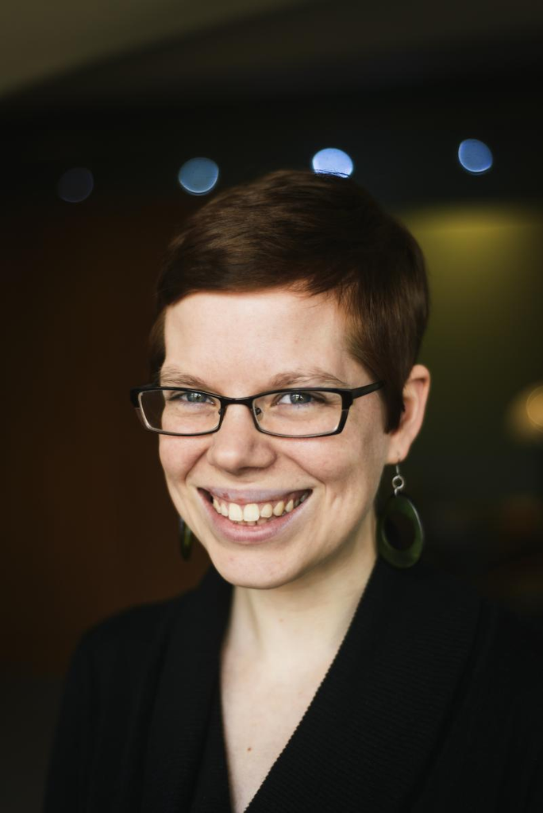

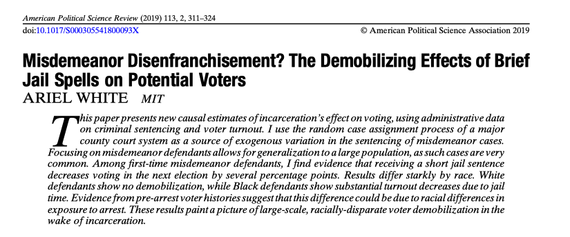

## White (2019), Figure 2

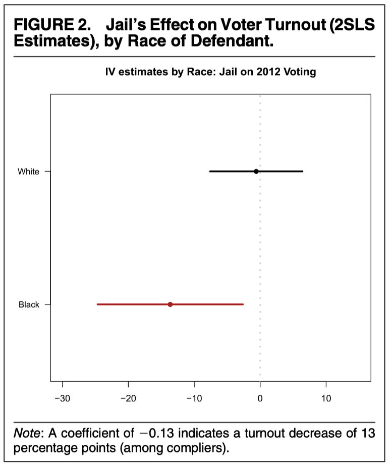

White (2019)